# Palgen_Second_Gating_check

Lucy Quirant

6/6/2019

## 0.1 Goal

Find out if the `fcs` files are gated to NK cells. Two baseline available, 19 days before first injection (BPD019) and just before the first injection (PPD000), however for the second time point only 3 out of 4 samples are available.

## 0.2 Prerequisites

```r
library("flowCore")
library("tidyverse")
library("magrittr")
```

## 0.3 Load Data

Manually downloaded fcs file from [here](http://flowrepository.org/id/FR-FCM-ZYPY).

```r
fcs = read.FCS("FlowRepository_FR-FCM-ZYPY_files/BPD019H00_BB078.fcs", transformation = FALSE)
tb_fcs = as_tibble(exprs(fcs))
isotope = pData(parameters(fcs))[,"name"]
protein_name = pData(parameters(fcs))[,"desc"]
instrument_min = pData(parameters(fcs))[,"minRange"]
insturment_max = pData(parameters(fcs))[,"maxRange"]
tb_marker = tibble(isotope, protein_name, instrument_min, insturment_max)
tb_fcs %<>% rename_at(vars(tb_marker$isotope), ~ tb_marker$protein_name)
exclude_cols = which(names(tb_fcs) %in%
                       c("Time", "cells", "File Number", "Cell_length"))
tb_fcs = tb_fcs[, -exclude_cols]
```

## 0.4 Plot Expressions

According to their paper in Table 2, page 4:

“For each sample, the number of leukocytes detected by the CyTOF (after exclusion of double-positive CD3+CD66+ eosinophils) is indicated. Not available samples are indicated na.”

So let’s check the CD3 and CD66 markers.

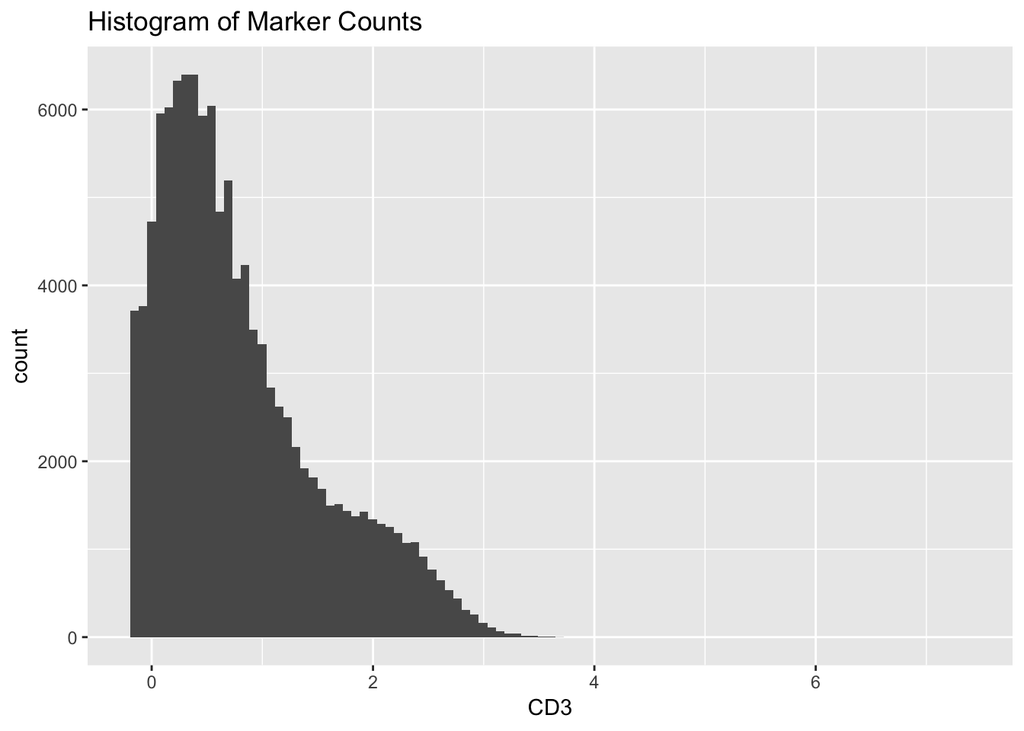

```r
plot_marker = function(pname) {
  limits = tb_marker %>% dplyr::filter(protein_name == pname)
  # variance stabilizing transformation
  varstab = function(x) asinh(x/5)
  tb_fcs %>%
    mutate_all(varstab) %>%
    ggplot(aes_string(pname)) +
    geom_histogram(bins = 100) +
    xlim(varstab(limits$instrument_min),
         varstab(limits$insturment_max)) +
    ggtitle("Histogram of Marker Counts")
}
plot_marker("CD3")
```

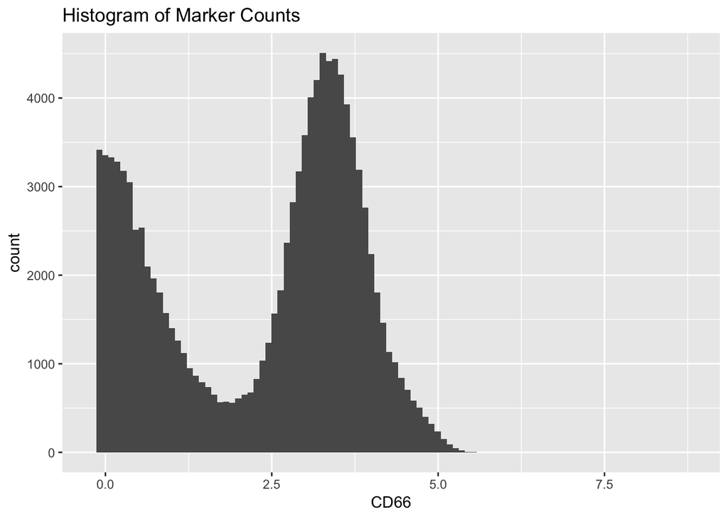

```r
plot_marker("CD66")
```

According to their paper on page 6:

“NK cells were gated as CD66-CD3-CD20-CD14-CD8+ cells using FlowJo 9 software (FlowJo, Ashland, USA). The absolute count numbers were calculated as the percentage of NK cells among all cells × leukocyte count (CBC).”

So, let’s also check CD20, CD14, and CD8.

Furthermore, frequently NK cells are determined by CD56 and CD16 quantities (see paper).

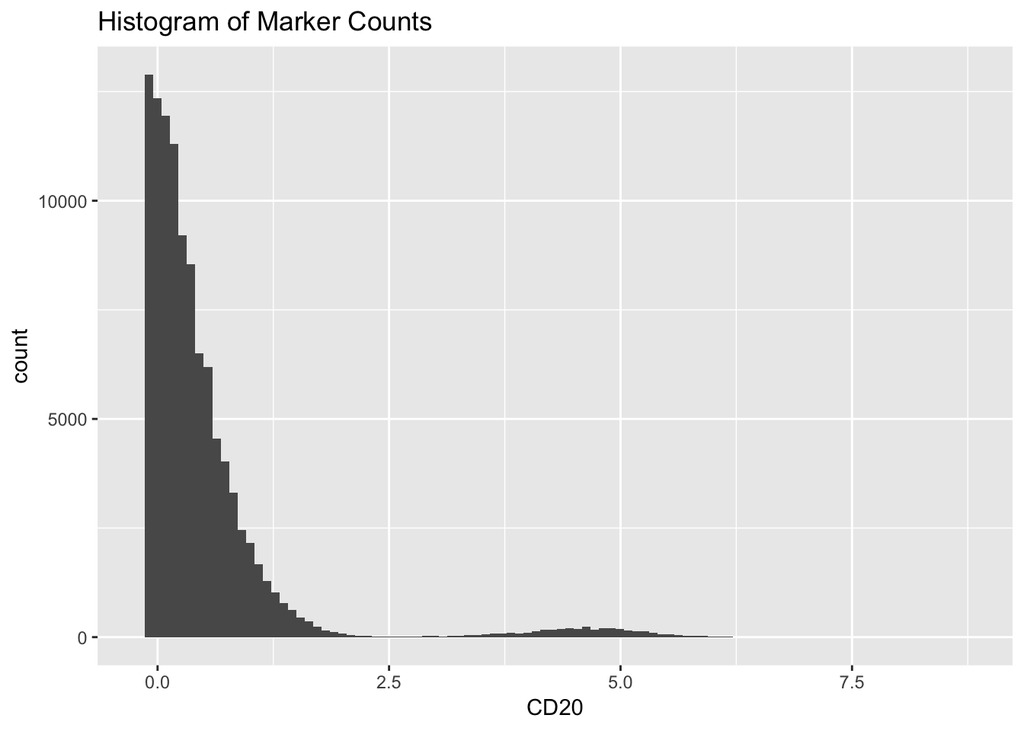

```r
plot_marker("CD20")
```

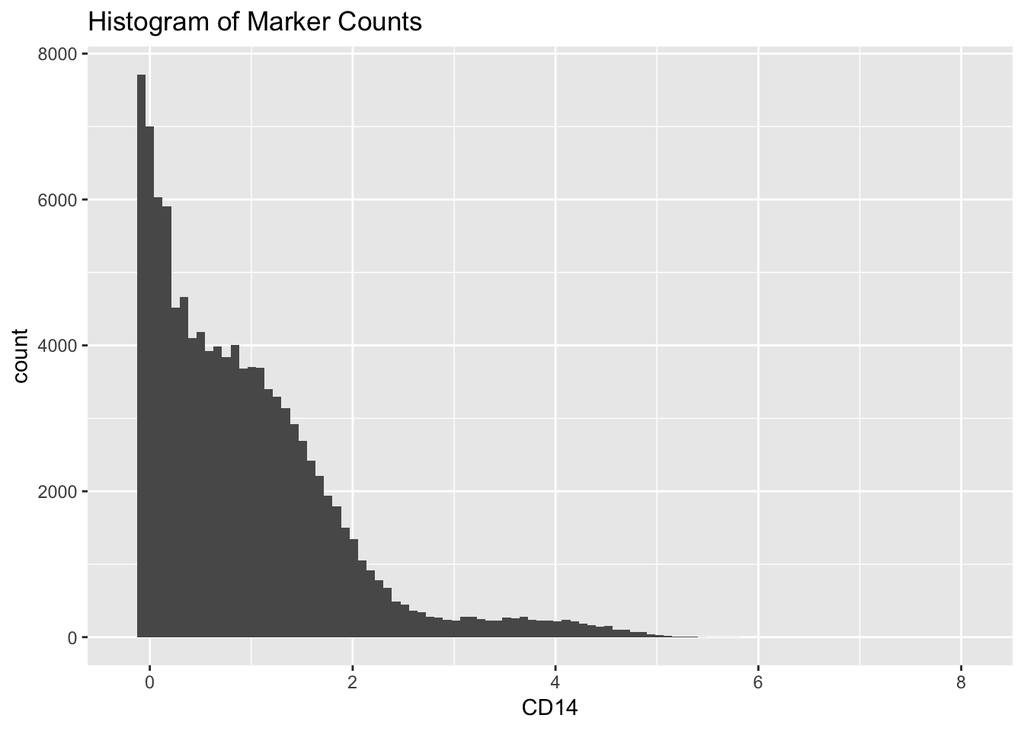

```r
plot_marker("CD14")
```

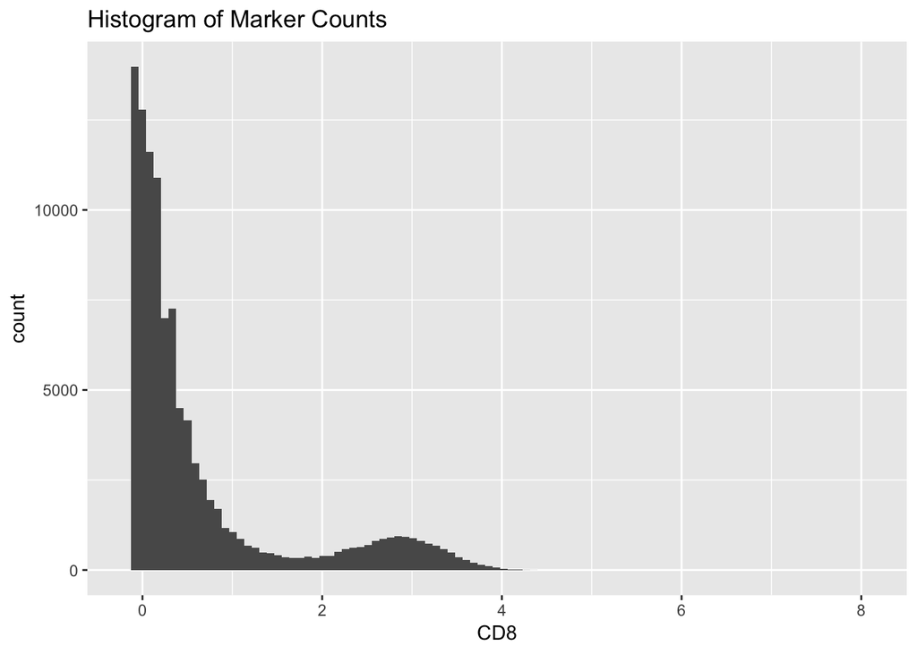

```r
plot_marker("CD8")
```

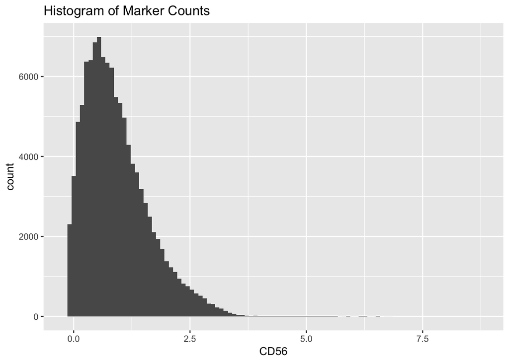

```r
plot_marker("CD56")
```

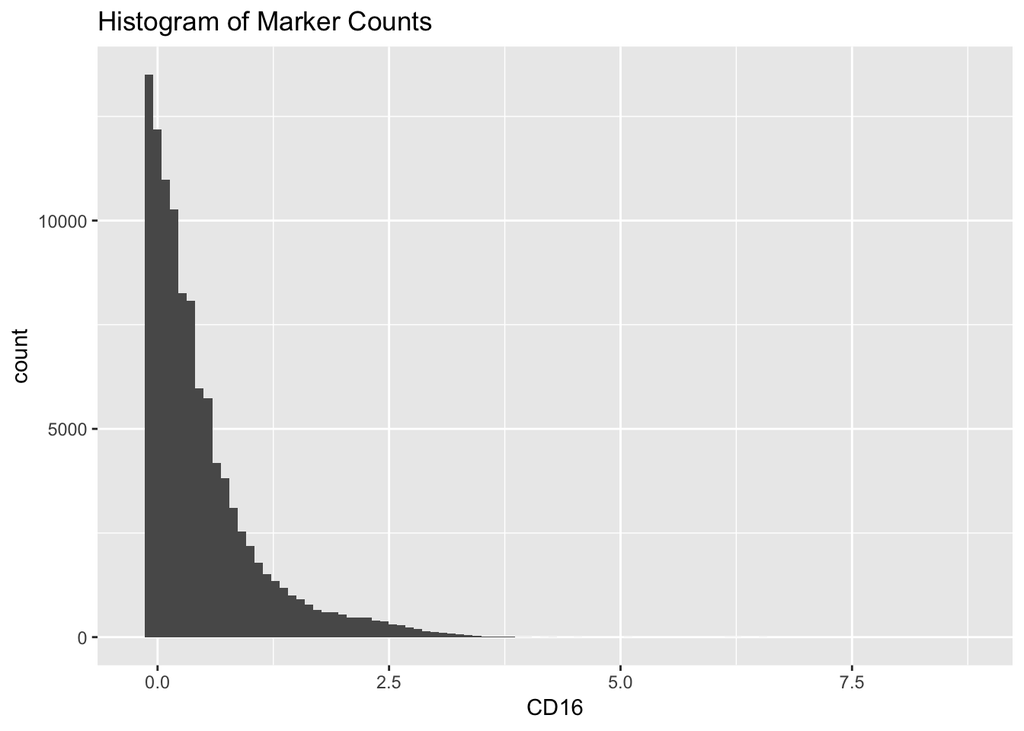

```r
plot_marker("CD16")
```

## 0.5 Conclusion

Two points that are unclear to me:

1. The CD66 are very high—they could be granulocytes.
2. The CD8 are very low—they could be negative, but should be positive according to their gating scheme.